# Exercise 2

Jacob John

Complete all **Exercises**, and submit answers to **VtopBeta**

## Create Dataset

1. Create a csv file with at least 20 entries on the following attributes:  
   Name Nominal  
   Age 1…100  
   Experience 1…15
2. Remove values of Experience and Fill with “NA”.
3. Replace few entries of Age with >100 values.
4. Print the dataset using R

```r
displaytable<-readRDS("exercisetwo.rds")
displaytable
```

```
##    Name Age Experience
## 1    A1   2         NA
## 2    A2  75          3
## 3    A3  10         NA
## 4    A4 100         NA
## 5    A5  86         15
## 6    A6  41          4
## 7    A7  76          6
## 8    A8  23          5
## 9    A9  41         13
## 10  A10  85          4
## 11  A11  85         10
## 12  A12 145         NA
## 13  A13   5         NA
## 14  A14  41          8
## 15  A15   4         NA
## 16  A16  77         10
## 17  A17  14          9
## 18  A18  73          6
## 19  A19  32         12
## 20  A20  84         10
```

## Missing data

1. Display the content of the dataset by removing the missing value tuples.

```r
exercise<-readRDS("exercisetwo.rds")
exercise[complete.cases(exercise),]
```

```
##    Name Age Experience
## 2    A2  75          3
## 5    A5  86         15
## 6    A6  41          4
## 7    A7  76          6
## 8    A8  23          5
## 9    A9  41         13
## 10  A10  85          4
## 11  A11  85         10
## 14  A14  41          8
## 16  A16  77         10
## 17  A17  14          9
## 18  A18  73          6
## 19  A19  32         12
## 20  A20  84         10
```

2. Calculate the mean of the attribute without considering the missing values.

```r
data_mean <- mean(exercise$Age,na.rm=TRUE)
data_mean
```

```
## [1] 54.95
```

3. Display the content of the dataset by replacing the ‘NA’ with mean of the attribute.

```r
exercisedata<-readRDS("exercisetwo.rds")
exercisedata$Experience[is.na(exercisedata$Experience)] <- mean(exercisedata$Experience,na.rm = TRUE)
exercisedata
```

```
##    Name Age Experience
## 1    A1   2   8.214286
## 2    A2  75   3.000000
## 3    A3  10   8.214286
## 4    A4 100   8.214286
## 5    A5  86  15.000000
## 6    A6  41   4.000000
## 7    A7  76   6.000000
## 8    A8  23   5.000000
## 9    A9  41  13.000000
## 10  A10  85   4.000000
## 11  A11  85  10.000000
## 12  A12 145   8.214286
## 13  A13   5   8.214286
## 14  A14  41   8.000000
## 15  A15   4   8.214286
## 16  A16  77  10.000000
## 17  A17  14   9.000000
## 18  A18  73   6.000000
## 19  A19  32  12.000000
## 20  A20  84  10.000000
```

## Outlier Detection

### Method 1

4. Replace the age value above 100 with “NA” and print the current dataset.

```r
exercisedata$Age[exercisedata$Age>100] <- NA
exercisedata
```

```
##    Name Age Experience
## 1    A1   2   8.214286
## 2    A2  75   3.000000
## 3    A3  10   8.214286
## 4    A4 100   8.214286
## 5    A5  86  15.000000
## 6    A6  41   4.000000
## 7    A7  76   6.000000
## 8    A8  23   5.000000
## 9    A9  41  13.000000
## 10  A10  85   4.000000
## 11  A11  85  10.000000
## 12  A12  NA   8.214286
## 13  A13   5   8.214286
## 14  A14  41   8.000000
## 15  A15   4   8.214286
## 16  A16  77  10.000000
## 17  A17  14   9.000000
## 18  A18  73   6.000000
## 19  A19  32  12.000000
## 20  A20  84  10.000000
```

5. Replace the “NA” in age with Mean of age.

```r
exercisedata$Age[is.na(exercisedata$Age)] <- data_mean
exercisedata
```

```
##    Name    Age Experience
## 1    A1   2.00   8.214286
## 2    A2  75.00   3.000000
## 3    A3  10.00   8.214286
## 4    A4 100.00   8.214286
## 5    A5  86.00  15.000000
## 6    A6  41.00   4.000000
## 7    A7  76.00   6.000000
## 8    A8  23.00   5.000000
## 9    A9  41.00  13.000000
## 10  A10  85.00   4.000000
## 11  A11  85.00  10.000000
## 12  A12  54.95   8.214286
## 13  A13   5.00   8.214286
## 14  A14  41.00   8.000000
## 15  A15   4.00   8.214286
## 16  A16  77.00  10.000000
## 17  A17  14.00   9.000000
## 18  A18  73.00   6.000000
## 19  A19  32.00  12.000000
## 20  A20  84.00  10.000000
```

### Method 2

6. Use the same dataset and change the value of age to lie outside the range of 100. Apply box plot and scatter plot to find the outliers.

```r
exercisedata$Age[is.na(exercisedata$Age)==data_mean] <- 145
exercisedata
```

```
##    Name    Age Experience
## 1    A1   2.00   8.214286
## 2    A2  75.00   3.000000
## 3    A3  10.00   8.214286
## 4    A4 100.00   8.214286
## 5    A5  86.00  15.000000
## 6    A6  41.00   4.000000
## 7    A7  76.00   6.000000
## 8    A8  23.00   5.000000
## 9    A9  41.00  13.000000
## 10  A10  85.00   4.000000
## 11  A11  85.00  10.000000
## 12  A12  54.95   8.214286
## 13  A13   5.00   8.214286
## 14  A14  41.00   8.000000
## 15  A15   4.00   8.214286
## 16  A16  77.00  10.000000
## 17  A17  14.00   9.000000
## 18  A18  73.00   6.000000
## 19  A19  32.00  12.000000
## 20  A20  84.00  10.000000
```

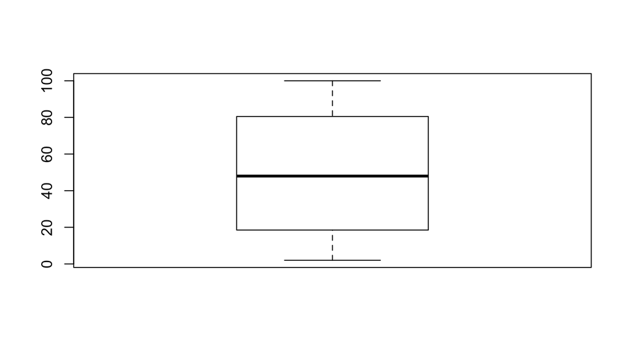

```r
boxplot(exercisedata$Age)
```

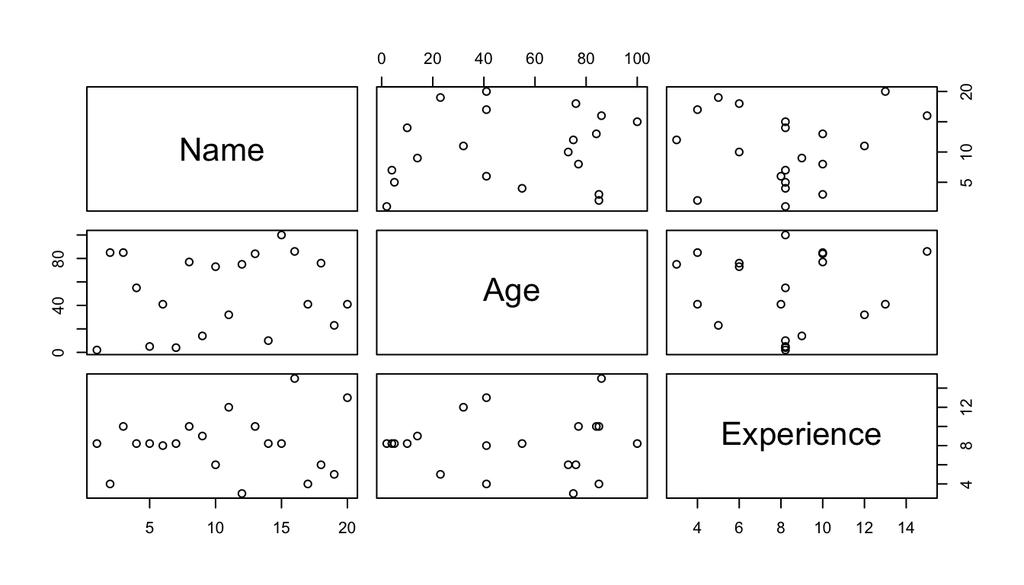

```r
plot(exercisedata)
```

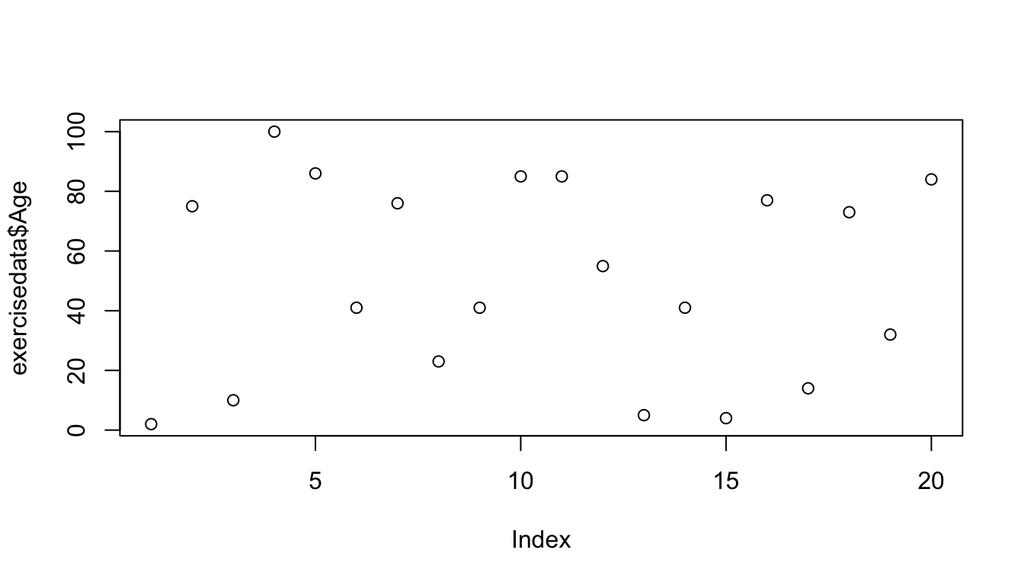

```r
plot(exercisedata$Age)
```

## Redundancy Check

7. Repeat the experience column as new attribute Exp. Find the correlation between age, Exp & experience.

```r
exercisedata$Exp <- exercisedata$Experience
exercisedata
```

```
##    Name    Age Experience       Exp
## 1    A1   2.00   8.214286  8.214286
## 2    A2  75.00   3.000000  3.000000
## 3    A3  10.00   8.214286  8.214286
## 4    A4 100.00   8.214286  8.214286
## 5    A5  86.00  15.000000 15.000000
## 6    A6  41.00   4.000000  4.000000
## 7    A7  76.00   6.000000  6.000000
## 8    A8  23.00   5.000000  5.000000
## 9    A9  41.00  13.000000 13.000000
## 10  A10  85.00   4.000000  4.000000
## 11  A11  85.00  10.000000 10.000000
## 12  A12  54.95   8.214286  8.214286
## 13  A13   5.00   8.214286  8.214286
## 14  A14  41.00   8.000000  8.000000
## 15  A15   4.00   8.214286  8.214286
## 16  A16  77.00  10.000000 10.000000
## 17  A17  14.00   9.000000  9.000000
## 18  A18  73.00   6.000000  6.000000
## 19  A19  32.00  12.000000 12.000000
## 20  A20  84.00  10.000000 10.000000
```

```r
corf <- cor(data.frame(exercisedata$Age,exercisedata$Experience,exercisedata$Exp))
corf
```

```
##                         exercisedata.Age exercisedata.Experience
## exercisedata.Age             1.000000000             0.008652845
## exercisedata.Experience      0.008652845             1.000000000
## exercisedata.Exp             0.008652845             1.000000000
##                         exercisedata.Exp
## exercisedata.Age             0.008652845
## exercisedata.Experience      1.000000000
## exercisedata.Exp             1.000000000
```